# respectables

## Availability

`respectables` is funded by and is copyright F Hoffman La Roche. It has been released open source under the Artistic-2.0 License.

Source code and dev version: https://github.com/Roche/respectables

CRAN release forthcoming

## Relational Data

## Model - Multiple Tables and Foreign Keys

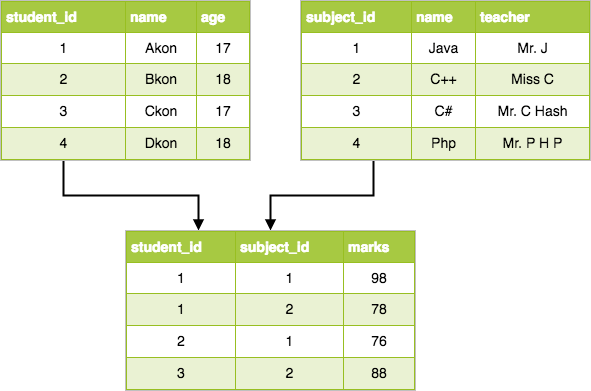

## Enter Müller’s `dm` Package

- Combine `data.frame`s into relational database
- Declare foreign key style relationships
- Check if the data meet constraints imposed by foreign keys

## `dm` is great so why are we here?

- `dm` assumes data already exists
- No tooling for *simulating* data under relational constraints

## `respectables` - Recipe-based Simulation of Relational Data

## Recipes You Say?

[figure not shown]

## Two Types of Data Interdependence

- **Intra**table
  - Height depends on gender
  - End date depends on start date
- **Inter**table
  - Foreign key relationship
  - Purchase orders depend on customer, store, product info

## Example Independent Data Table - Silly Customer Data

- `ID` - unique customer ID
- `STUFFLEVEL` - randomly sampled from `high` and `low` values
- `KEYSIZE` - normally distributed with mean depending on `STUFFLEVEL`
- `ACCT_OPEN`, `ACCT_CLOSED` - dates account was opened and closed

## Ingredients - Variable Generating Functions

```r
sample_fct(c("low", "hi"), 4)
```

```
## [1] hi  hi  low hi
## Levels: low hi
```

```r
keysize(.df = data.frame(STUFFLEVEL = rep(c("low", "high"), c(2, 2))))
```

```
## [1] 32.33883 22.38373 56.29206 57.25272
```

```r
acct_dates(2, firstopen = "2010-01-01")
```

```
##             ACCT_OPEN ACCT_CLOSED
## 1 2013-03-15 01:46:56        <NA>
## 2 2019-06-27 21:51:23        <NA>
```

## Recipe

```r
lastdate <- Sys.time()
acctdate_vars <- c("ACCT_OPEN", "ACCT_CLOSED")
recipe <- tribble(~variables,   ~dependencies, ~func,          ~func_args,                   ~keep,
                  "ID",         no_deps,      "subjid_func",  list(prefix="ID", sep=""),     TRUE,
                  "STUFFLEVEL", no_deps,      sample_fct,     list(x = c("high", "low")),    TRUE,
                  "KEYSIZE",    "STUFFLEVEL", "keysize",      NULL,                          TRUE,
                  acctdate_vars, no_deps,     "acct_dates",   list(firstopen = "2015-01-01",
                                                                   lastclose = lastdate),  TRUE)
```

## Silly Data

```r
sillydata <- gen_table_data(N = 500, recipe = recipe)
head(sillydata)
```

```
##      ID STUFFLEVEL   KEYSIZE           ACCT_OPEN ACCT_CLOSED
## 1 ID001        low  4.962892 2016-02-17 09:52:10        <NA>
## 2 ID002        low 29.547669 2021-06-18 19:48:41        <NA>
## 3 ID003        low  1.493617 2015-03-12 19:54:57        <NA>
## 4 ID004       high 40.126547 2016-01-23 22:14:53        <NA>
## 5 ID005       high 43.170109 2016-11-13 04:56:16        <NA>
## 6 ID006        low 25.737637 2020-06-04 03:23:57        <NA>
```

## Silly Data - The `dplyr` Way

```r
sillydata2 <- data.frame(ID = subjid_func(n = 500, prefix = "ID", sep = "")) %>%
    mutate(STUFFLEVEL = sample_fct(n = n(), x = c("high", "low")),
           KEYSIZE = rnorm(n(), mean = ifelse(STUFFLEVEL == "high", 50, 20), sd = 15),
           ACCT_OPEN = rand_posixct(n = n(), start = "2015-01-01", end = lastdate),
           ACCT_CLOSE = rand_posixct(n = n(), start = ACCT_OPEN, end = lastdate),
           ACCT_CLOSE = ifelse(runif(n()) >= .15, NA_integer_, ACCT_CLOSE),
           ACCT_CLOSE = as.POSIXct(ACCT_CLOSE, origin = pct_orig))
head(sillydata2)
```

```
##      ID STUFFLEVEL  KEYSIZE           ACCT_OPEN ACCT_CLOSE
## 1 ID001       high 54.16225 2019-01-04 15:03:38       <NA>
## 2 ID002       high 55.66730 2021-05-21 21:52:50       <NA>
## 3 ID003       high 29.67463 2017-01-22 07:59:52       <NA>
## 4 ID004       high 58.99437 2018-05-18 16:43:46       <NA>
## 5 ID005       high 53.33188 2018-07-01 18:01:13       <NA>
## 6 ID006       high 56.22217 2020-05-12 09:14:06       <NA>
```

## Recipes Are Still Nice

- Reusable
- Automatically parameterized by `func` and `func_args`
- Support *jointly* generating 2+ variables
- Easy to extend

## Simulating Data Under Foreign-Key Constraints

## Scaffold Tables And Scaffolding Join Recipes

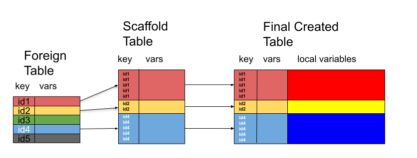

## Speaking With Silly Wallets - Our Sillyfolk Go Shopping

## Sillyfolk Are Silly Shoppers

- Some open an account but never go shopping
- Some go shopping many times
- All buy only one item per store visit
  - At random from items currently being sold
  - regardless of previous purchases

## Scaffolding Sillyfolk Shopping Trips

```r
sjfun <- rand_per_key("ID", mincount = 0, maxcount = 5, prop_present = 1)

scaff <- sjfun(.dbtab = sillydata)
table(table(scaff$ID))
```

```
##
##  1  2  3  4  5
## 69 78 97 84 90
```

```r
length(unique(scaff$ID))
```

```
## [1] 418
```

## Our Scaffolding Join Recipe

```r
sjrecipe <- tribble(~foreign_tbl, ~foreign_key, ~func,  ~func_args,
                    "sillycust",  "ID",         sjfun,  list())
```

## What To Buy When Silly Shopping

```r
## lookup table for products and when they were available for purchase
products <- tribble(~PRODUCTID, ~DESC,          ~AVAIL_ST,    ~AVAIL_END,
                    "PROD1",    "Doodad",       "2010-01-01", lastdate,
                    "PROD2",    "HLight Fluid", "2010-01-01", lastdate,
                    "PROD3",    "Mcguffin",     "2017-01-01", as.POSIXct("2017-12-31"),
                    "PROD4",    "Spanner",      "2010-01-01", lastdate,
                    "PROD5",    "Thingbat",     "2015-03-03", lastdate,
                    "PROD6",    "Thingbat v2",  "2018-03-03", lastdate)
```

## Ingredients Redux

```r
tmpbuys <- buydate_func(.df = scaff[1:2,], end = lastdate)
tmpbuys
```

```
##   BUYID             BUYDATE
## 2     1 2021-06-19 01:07:15
## 1     2 2021-06-29 20:20:51
```

```r
prods_func(.df = tmpbuys)
```

```
## # A tibble: 2 x 2
##   PRODUCTID DESC
##   <chr>     <chr>
## 1 PROD2     HLight Fluid
## 2 PROD6     Thingbat v2
```

## Our Silly Shopping Recipe

```r
buycols <- c("BUYID", "BUYDATE")
buycoldeps <- c("ID", acctdate_vars)
prodcols <- c("PRODUCTID", "DESC")
buys_rec <- tribble(~variables, ~dependencies,  ~func,          ~func_args, ~keep,
                    buycols,    buycoldeps,     "buydate_func", NULL,       TRUE,
                    prodcols,   "BUYDATE",      "prods_func",   NULL,       TRUE)

buysdf <- gen_reljoin_table(sjrecipe, buys_rec, db = list(sillycust = sillydata))
head(buysdf[, c("ID", buycols, prodcols)], n = 4)
```

```
##      ID BUYID             BUYDATE PRODUCTID         DESC
## 3 ID001   418 2019-04-19 08:50:30     PROD1       Doodad
## 4 ID001   634 2020-02-14 09:44:56     PROD4      Spanner
## 2 ID001   756 2020-06-23 01:32:00     PROD2 HLight Fluid
## 1 ID001  1105 2021-05-16 06:58:59     PROD4      Spanner
```

## Specifying and Simulating Full Relational Datasets

## Cookbooks

[figure not shown]

## Our Full Silly Data

```r
cookbook <- tribble( ~table,     ~scaff_rec, ~data_rec, ~na_rec,
                    "sillycust", no_rec,     recipe,    no_rec,
                    "sillybuys", sjrecipe,   buys_rec,  no_rec)

fullsilly <- gen_data_db(cookbook)
lapply(fullsilly, head, 2)
```

```
## $sillycust
##      ID STUFFLEVEL  KEYSIZE           ACCT_OPEN ACCT_CLOSED
## 1 ID001       high 60.15057 2020-06-08 11:42:45        <NA>
## 2 ID002       high 38.32328 2018-08-13 00:45:36        <NA>
##
## $sillybuys
##      ID BUYID             BUYDATE PRODUCTID        DESC
## 2 ID001   731 2020-08-20 05:48:41     PROD5    Thingbat
## 4 ID001   789 2020-10-09 22:56:20     PROD6 Thingbat v2
```

## Slide Garage

## Modularity When Simulating Complex Data

`tbl_df` containing the following list columns:

- `variables` -variables to generate
- `dependencies` - variable depenedencies
- `func` - function to generatate data
- `func_args` - [list] arguments for `func`
- `keep` - [logical] should `variables` be kept

## Recipes cont

- Each row declares how data for one or more variables should be generated
- Rows can appear in any order
  - `respectables` determines run order based on dependency declaration
- Simulation logic is declared modularly
  - Thus can be tested modularly

## Foreign Key Relationship Examples

- Patients[PatientID] -> Dr_Visits[PatientID]
  - patient can have 0, 1, or many visits
- Purchases[CustomerID, StoreID, ProductID] -> Customers[CustomerID], Stores[StoreID], Products[ProductID]

## Creating Buys

We define `buydate_func` which

- Accepts .df which contains `ID`, `ACCT_OPEN` and `ACCT_CLOSE`
- Creates `BUYDATE` and `BUYID` such that
  - `BUYID` are sequental globally
  - `BUYDATE` are sequential within `ID`

## Deciding What To Buy

`prods_func`

- Accepts `.df` containing `BUYDATE`
- Determines what products were avaialable on `BUYDATE` for each transaction
- Randomly selects an available product per transaction

## Two Stage Process

- Scaffolding - Determine dimensions based on foreign table
- Data Generation - Normal

## Recipes Are Still Nice

```r
recipe2 <- recipe
recipe2$func_args[[3]] <- list(high=20, low = 50)

sillydata2 <- gen_table_data(N= 500, recipe = recipe2)
head(sillydata2)
```

```
##      ID STUFFLEVEL   KEYSIZE           ACCT_OPEN ACCT_CLOSED
## 1 ID001       high 31.046826 2020-05-01 08:43:09        <NA>
## 2 ID002        low 17.799029 2015-02-17 20:51:01        <NA>
## 3 ID003        low 64.994365 2021-06-25 13:45:52        <NA>
## 4 ID004       high 39.840909 2021-04-19 01:55:23        <NA>
## 5 ID005       high  7.092532 2020-03-27 04:15:16        <NA>
## 6 ID006       high 23.897347 2015-02-21 15:09:03        <NA>
```

## Also

Sometimes you really do want to *jointly* generate 2+ variables

- Not in `mutate()` land anymore
- Need a pipeable wrapper around your logic
  - `function(x, ...) cbind(x, real_logic(x, ...))`
  - Doable, of course, but doesn’t really add anything

## Scaffolding: Random Events Per Id

- `rand_per_key` function factory
  - takes `keyvar`, `mincount`, `maxcount`, and `prop_present`
  - returns scaffolding function suitable for use in scaffolding join recipe